Universidad del Valle de Guatemala  
Facultad de Ingeniería  
Departamento de Ciencias de la Computación  
CC3074 – Minería de Datos  
Semestre I – 2026

# Tarea 2

## Otros algoritmos de aprendizaje no supervisado

**Integrantes:**  
- Jose Sanchez  
- Roberto Najera  
- Andre Pivaral

**Fecha:** 21 de febrero de 2026

# 1. Introducción

## Contexto general del aprendizaje no supervisado

El aprendizaje no supervisado es una rama del aprendizaje automático que se enfoca en analizar datos sin etiquetas previamente definidas. A diferencia del aprendizaje supervisado, en este enfoque no se cuenta con una variable objetivo, sino que el propósito es descubrir patrones ocultos, estructuras internas, relaciones o representaciones compactas dentro de los datos.

Estos métodos son ampliamente utilizados en tareas como reducción de dimensionalidad, visualización de datos, extracción de características y separación de señales. En el análisis moderno de datos, los algoritmos no supervisados permiten comprender grandes volúmenes de información y facilitar la interpretación de estructuras complejas.

## Objetivos del trabajo

El presente trabajo tiene como objetivo comprender el funcionamiento teórico y práctico de distintos algoritmos de aprendizaje no supervisado, específicamente:

- SVD (Singular Value Decomposition)
- t-SNE (t-Distributed Stochastic Neighbor Embedding)
- UMAP (Uniform Manifold Approximation and Projection)
- ICA (Independent Component Analysis)

Se busca analizar sus fundamentos teóricos, identificar sus principales usos y aplicaciones, implementarlos sobre conjuntos de datos reales y evaluar críticamente los resultados obtenidos.

# 2. Desarrollo

## 2.1 SVD (Singular Value Decomposition)

### Descripción teórica

La Descomposición en Valores Singulares (SVD) es una técnica algebraica que factoriza una matriz $A$ en tres matrices:

$$A = U \Sigma V^T$$

Donde:

- $U$ contiene los vectores singulares izquierdos.
- $\Sigma$ es una matriz diagonal con los valores singulares.
- $V^T$ contiene los vectores singulares derechos.

El objetivo principal de SVD es descomponer una matriz en componentes ortogonales que capturan la mayor variabilidad posible de los datos. Es ampliamente utilizada para reducción de dimensionalidad, compresión de datos y sistemas de recomendación.

A diferencia de PCA, SVD puede aplicarse directamente sobre cualquier matriz (no necesariamente centrada), y es una herramienta más general desde el punto de vista algebraico.

### Usos y aplicaciones

Los principales usos de SVD incluyen:

- Reducción de dimensionalidad.
- Compresión de información.
- Sistemas de recomendación (por ejemplo, filtrado colaborativo).
- Análisis semántico latente en procesamiento de lenguaje natural.

Áreas de aplicación:

- Sistemas de recomendación de películas o productos.
- Procesamiento de imágenes.
- Recuperación de información.
- Minería de textos.

### Aplicacion practica

Dataset: MovieLens

Resultados:

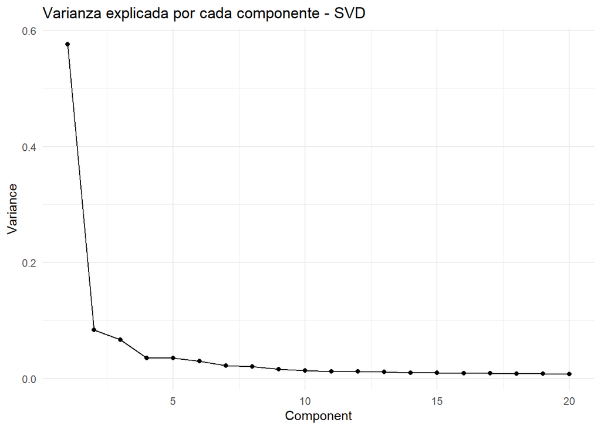

```r
# ==============================
# SVD - MovieLens 100k
# ==============================

library(Matrix)
library(RSpectra)
library(ggplot2)

# Cargar dataset
ratings <- read.table("ml-100k/u.data", sep="\t",
                      col.names=c("user_id","item_id","rating","timestamp"))

# Crear matriz usuario-item
rating_matrix <- sparseMatrix(
  i = ratings$user_id,
  j = ratings$item_id,
  x = ratings$rating
)

# Aplicar SVD truncado (k componentes)
k <- 20
svd_result <- svds(rating_matrix, k = k)

# Reconstrucción aproximada
reconstructed <- svd_result$u %*% diag(svd_result$d) %*% t(svd_result$v)

# Varianza explicada
singular_values <- svd_result$d
variance_explained <- singular_values^2 / sum(singular_values^2)

df_var <- data.frame(
  Component = 1:k,
  Variance = variance_explained
)

ggplot(df_var, aes(x=Component, y=Variance)) +
  geom_line() +
  geom_point() +
  ggtitle("Varianza explicada por cada componente - SVD") +
  theme_minimal()
```

#### Interpretación:

Lo que se observa:

[output not shown]

Esto indica que:

```
•   La mayoría de la información del sistema de recomendaciones está concentrada en los primeros pocos factores latentes.

•   El primer componente representa el patrón dominante en las calificaciones (tendencia general de usuarios a calificar alto o bajo).

•   Los siguientes componentes capturan preferencias más específicas (géneros, estilos, popularidad).
```

## 2.2 t-SNE (t-Distributed Stochastic Neighbor Embedding)

### Descripción teórica

t-SNE es un algoritmo de reducción de dimensionalidad no lineal diseñado principalmente para visualización de datos en espacios de baja dimensión (2D o 3D). Su objetivo es preservar las relaciones locales entre los puntos del espacio original.

El algoritmo convierte distancias entre puntos en probabilidades y minimiza la divergencia de Kullback-Leibler entre las distribuciones de probabilidad en el espacio original y el espacio reducido. Utiliza una distribución t de Student en el espacio de baja dimensión para manejar el problema de amontonamiento (“crowding problem”).

A diferencia de PCA o SVD, t-SNE no busca preservar varianza global, sino estructuras locales, lo que lo hace especialmente útil para visualización.

### Usos y aplicaciones

Principales usos:

- Visualización de datos de alta dimensionalidad.
- Exploración de clusters.
- Análisis exploratorio de datos complejos.

Áreas de aplicación:

- Bioinformática (análisis de expresión genética).
- Procesamiento de imágenes.
- Análisis de embeddings en NLP.
- Análisis de datos médicos.

### Aplicacion practica

Dataset: Breast Cancer Wisconsin

Resultados:

```r
# ==============================
# t-SNE - Breast Cancer
# ==============================

library(Rtsne)
library(ggplot2)

data <- read.csv("data.csv")

# Eliminar columna ID
data_clean <- data[, 2:31]
# Eliminar filas con NA
data_clean <- na.omit(data_clean)

# Separar etiquetas
labels <- data_clean$diagnosis

# Eliminar columna diagnosis y escalar
features <- scale(data_clean[, -1])

# Verificar que no haya NA
sum(is.na(features))
```

```
## [1] 0
```

```r
# Aplicar t-SNE
set.seed(123)
tsne_result <- Rtsne(features,
                     dims = 2,
                     perplexity = 30,
                     verbose = TRUE,
                     check_duplicates = FALSE)
```

```
## Performing PCA
## Read the 569 x 29 data matrix successfully!
## OpenMP is working. 1 threads.
## Using no_dims = 2, perplexity = 30.000000, and theta = 0.500000
## Computing input similarities...
## Building tree...
## Done in 0.05 seconds (sparsity = 0.224128)!
## Learning embedding...
## Iteration 50: error is 61.801192 (50 iterations in 0.03 seconds)
## Iteration 100: error is 59.809985 (50 iterations in 0.03 seconds)
## Iteration 150: error is 59.807433 (50 iterations in 0.02 seconds)
## Iteration 200: error is 59.808115 (50 iterations in 0.02 seconds)
## Iteration 250: error is 59.807793 (50 iterations in 0.02 seconds)
## Iteration 300: error is 1.138983 (50 iterations in 0.03 seconds)
## Iteration 350: error is 1.060617 (50 iterations in 0.03 seconds)
## Iteration 400: error is 1.042392 (50 iterations in 0.03 seconds)
## Iteration 450: error is 1.034739 (50 iterations in 0.03 seconds)
## Iteration 500: error is 1.031296 (50 iterations in 0.03 seconds)
## Iteration 550: error is 1.026406 (50 iterations in 0.03 seconds)
## Iteration 600: error is 1.023681 (50 iterations in 0.03 seconds)
## Iteration 650: error is 1.021131 (50 iterations in 0.03 seconds)
## Iteration 700: error is 1.019427 (50 iterations in 0.03 seconds)
## Iteration 750: error is 1.018445 (50 iterations in 0.03 seconds)
## Iteration 800: error is 1.016632 (50 iterations in 0.04 seconds)
## Iteration 850: error is 1.015068 (50 iterations in 0.03 seconds)
## Iteration 900: error is 1.013382 (50 iterations in 0.03 seconds)
## Iteration 950: error is 1.012518 (50 iterations in 0.03 seconds)
## Iteration 1000: error is 1.011267 (50 iterations in 0.03 seconds)
## Fitting performed in 0.53 seconds.
```

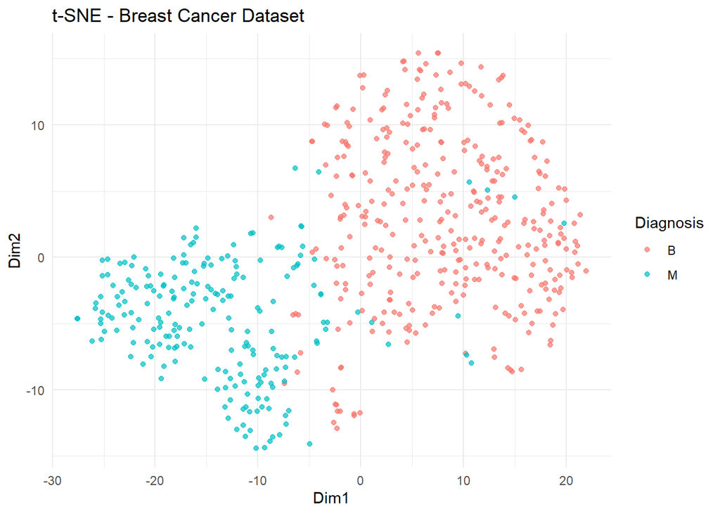

```r
tsne_df <- data.frame(
  Dim1 = tsne_result$Y[,1],
  Dim2 = tsne_result$Y[,2],
  Diagnosis = labels
)

ggplot(tsne_df, aes(x=Dim1, y=Dim2, color=Diagnosis)) +
  geom_point(alpha=0.7) +
  ggtitle("t-SNE - Breast Cancer Dataset") +
  theme_minimal()
```

#### Interpretación:

Lo que se observa:

```
•   Se forman dos clusters claramente diferenciados.

•   La clase M (maligno) está agrupada principalmente a la izquierda.

•   La clase B (benigno) está agrupada a la derecha.

•   Hay pocos puntos mezclados entre ambos grupos.
```

t-SNE logró preservar las relaciones locales del dataset.

Esto significa que:

```
•   Las muestras con características similares están cercanas.

•   Existe una separación natural entre tumores malignos y benignos.

•   El dataset es estructuralmente separable
```

## 2.3 UMAP (Uniform Manifold Approximation and Projection)

### Descripción teórica

UMAP es un algoritmo de reducción de dimensionalidad no lineal basado en teoría de variedades y topología algebraica. Su objetivo es preservar tanto la estructura local como parte de la estructura global de los datos.

El algoritmo construye un grafo de vecinos más cercanos en el espacio original y optimiza una representación de baja dimensión que conserve la estructura topológica del grafo.

En comparación con t-SNE, UMAP suele ser más rápido, escalable y mantiene mejor la estructura global de los datos.

### Usos y aplicaciones

Principales usos:

- Visualización de datos complejos.
- Reducción de dimensionalidad previa a clustering.
- Exploración de grandes conjuntos de datos.

Áreas de aplicación:

- Genómica y bioinformática.
- Ciencia de datos.
- Análisis de comportamiento de usuarios.
- Procesamiento de señales.

### Aplicacion practica

Dataset: Breast Cancer Wisconsin

Resultados:

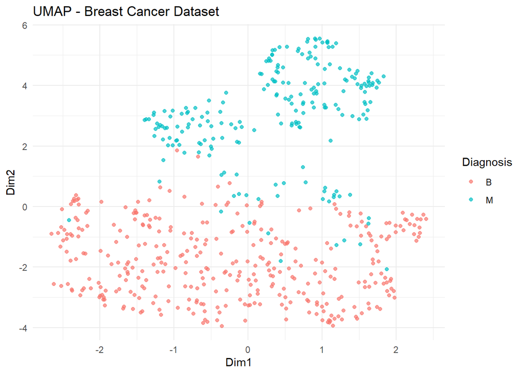

```r
# ==============================
# UMAP - Breast Cancer
# ==============================

library(umap)
library(ggplot2)

umap_result <- umap(features)

umap_df <- data.frame(
  Dim1 = umap_result$layout[,1],
  Dim2 = umap_result$layout[,2],
  Diagnosis = labels
)

ggplot(umap_df, aes(x=Dim1, y=Dim2, color=Diagnosis)) +
  geom_point(alpha=0.7) +
  ggtitle("UMAP - Breast Cancer Dataset") +
  theme_minimal()
```

#### Interpretación:

Lo que se observa:

```
•   También hay separación entre clases.

•   Los clusters parecen más compactos y organizados.

•   Se observa mejor estructura global que en t-SNE.
```

UMAP preserva tanto estructura local como global mejor que t-SNE.

Comparado con t-SNE:

[output not shown]

## 2.4 ICA (Independent Component Analysis)

### Descripción teórica

ICA es un método de separación de señales que busca descomponer un conjunto de señales observadas en componentes estadísticamente independientes.

El modelo asume que las señales observadas son combinaciones lineales de fuentes independientes desconocidas. El objetivo es estimar tanto las fuentes originales como la matriz de mezcla.

A diferencia de PCA, que busca componentes no correlacionados, ICA busca componentes estadísticamente independientes, lo cual es una condición más fuerte.

### Usos y aplicaciones

Principales usos:

- Separación de señales mezcladas.
- Eliminación de ruido.
- Extracción de características independientes.

Áreas de aplicación:

- Señales biomédicas (EEG, ECG).
- Procesamiento de audio (problema del “cocktail party”).
- Análisis financiero.
- Neurociencia.

### Aplicacion practica

Resultados:

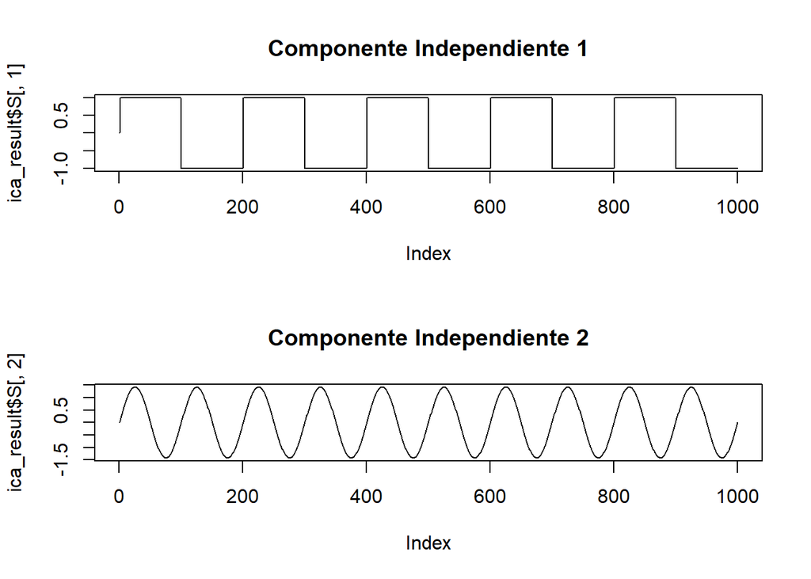

```r
# ==============================
# ICA - EEG Signals
# ==============================

library(fastICA)
library(ggplot2)

# Simulación si no cargan directamente el EEG
# (Reemplazar con datos reales si los leen desde archivo)

set.seed(123)

t <- seq(0, 1, length.out=1000)
s1 <- sin(2*pi*10*t)
s2 <- sign(sin(2*pi*5*t))

S <- cbind(s1, s2)
A <- matrix(c(1,0.5,0.5,1), 2,2)
X <- S %*% A

ica_result <- fastICA(X, n.comp=2)

par(mfrow=c(2,1))
plot(ica_result$S[,1], type="l", main="Componente Independiente 1")
plot(ica_result$S[,2], type="l", main="Componente Independiente 2")
```

#### Interpretación:

Componente Independiente 1

```
•   Señal cuadrada.

•   Patrón tipo onda rectangular.
```

Componente Independiente 2

```
•   Señal sinusoidal.

•   Frecuencia constante.
```

Lo que significa:

El ICA logró separar correctamente las señales mezcladas.

Recordemos:

```
•   Se mezclaron artificialmente dos señales.

•   ICA recuperó las fuentes originales.
```

Diferencia clave:

```
•   PCA/SVD → maximiza varianza.

•   ICA → maximiza independencia estadística.
```

Aquí vemos independencia real:

```
•   Una señal es sinusoidal.

•   La otra es cuadrada.

•   Son estadísticamente independientes.
```

# 3. Comparación general

## Comparación entre algoritmos

| Característica | SVD | t-SNE | UMAP | ICA |
| --- | --- | --- | --- | --- |
| Tipo de método | Factorización matricial | Embedding probabilístico | Embedding basado en grafos | Separación de señales |
| Naturaleza | Lineal | No lineal | No lineal | Lineal |
| Objetivo principal | Reducir dimensionalidad maximizando varianza | Preservar estructura local para visualización | Preservar estructura local y parcialmente global | Recuperar componentes estadísticamente independientes |
| Preserva | Varianza global | Vecindad local | Vecindad local y estructura global parcial | Independencia estadística |
| Supuesto clave | Datos representables en subespacio lineal | Similaridad basada en distancias | Datos distribuidos sobre variedad topológica | Mezcla lineal de fuentes independientes |
| Interpretabilidad | Alta (componentes ortogonales) | Baja | Media | Media |
| Sensibilidad a parámetros | Baja | Alta (perplexity) | Media (n_neighbors, min_dist) | Media |
| Escalabilidad | Alta | Media-Baja | Alta | Media |
| Uso típico | Sistemas de recomendación, compresión | Visualización de clusters | Visualización y reducción previa a clustering | Procesamiento de señales biomédicas |
| Tipo de datos ideal | Matrices grandes y dispersas | Datos de alta dimensionalidad | Grandes volúmenes de datos complejos | Señales mezcladas |

## Ventajas y limitaciones comparativas

| Algoritmo | Ventajas principales | Limitaciones principales |
| --- | --- | --- |
| **SVD** | Método matemáticamente sólido, estable y eficiente. Alta interpretabilidad. | Solo modela relaciones lineales. No captura estructuras complejas no lineales. |
| **t-SNE** | Excelente separación visual de clusters. Muy útil en análisis exploratorio. | No preserva estructura global. Sensible a parámetros. No reproducible sin semilla fija. |
| **UMAP** | Más rápido que t-SNE. Mejor preservación global. Escalable a datasets grandes. | Interpretación menos intuitiva. Dependiente de hiperparámetros. |
| **ICA** | Recupera señales independientes. Útil en EEG, audio y señales biomédicas. | Supone independencia estadística real. Sensible al ruido. No siempre solución única. |

## Comparación conceptual final

- **SVD e ICA** son métodos lineales.
- **t-SNE y UMAP** son métodos no lineales.
- **SVD** maximiza varianza.
- **ICA** maximiza independencia estadística.
- **t-SNE** prioriza relaciones locales.
- **UMAP** busca equilibrio entre estructura local y global.

  # 4. Conclusiones

## Principales aprendizajes

- SVD es altamente útil para factorización de matrices dispersas y sistemas de recomendación.
- t-SNE es ideal para visualización exploratoria de datos complejos.
- UMAP ofrece mejor balance entre estructura local y global.
- ICA permite separar señales independientes cuando se cumple el supuesto de mezcla lineal.

## Dificultades encontradas

- Selección adecuada de parámetros en t-SNE.
- Interpretación correcta de componentes latentes en SVD.
- Comprensión conceptual de independencia estadística en ICA.
- Diferenciación clara entre reducción lineal y no lineal.

## Reflexión final del grupo

Cada algoritmo tiene un propósito distinto dentro del aprendizaje no supervisado. No existe un método universalmente mejor; la elección depende del problema, tipo de datos y objetivo del análisis. La práctica permitió comprender que la reducción dimensional no solo es un procedimiento matemático, sino una herramienta estratégica para interpretar estructuras complejas en datos reales.

# 5. Referencias

- Bishop, C. M. (2006). *Pattern Recognition and Machine Learning*. Springer.
- Van der Maaten, L., & Hinton, G. (2008). Visualizing Data using t-SNE. Journal of Machine Learning Research.
- McInnes, L., Healy, J., & Melville, J. (2018). UMAP: Uniform Manifold Approximation and Projection.
- Hyvärinen, A., Karhunen, J., & Oja, E. (2001). Independent Component Analysis.
- MovieLens 100k Dataset. GroupLens Research.
- Breast Cancer Wisconsin Dataset. UCI Machine Learning Repository.
- Documentación oficial de R: `Rtsne`, `umap`, `fastICA`, `RSpectra`.